# Visualization and EDA 1

# Odds and Ends

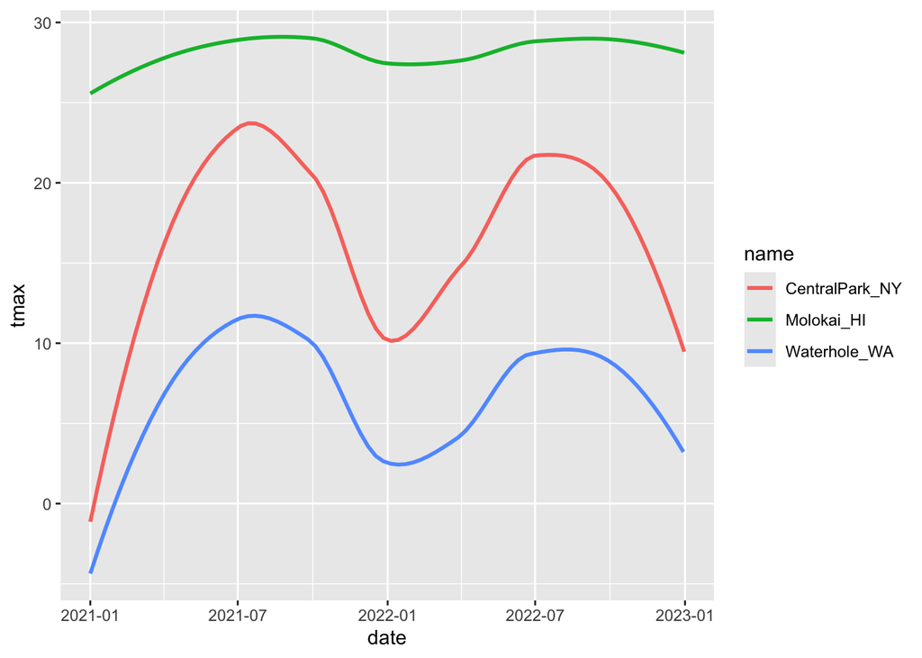

```r
weather_df |>
  ggplot(aes(x = date, y = tmax, color = name)) +
  geom_smooth(se = FALSE)
```

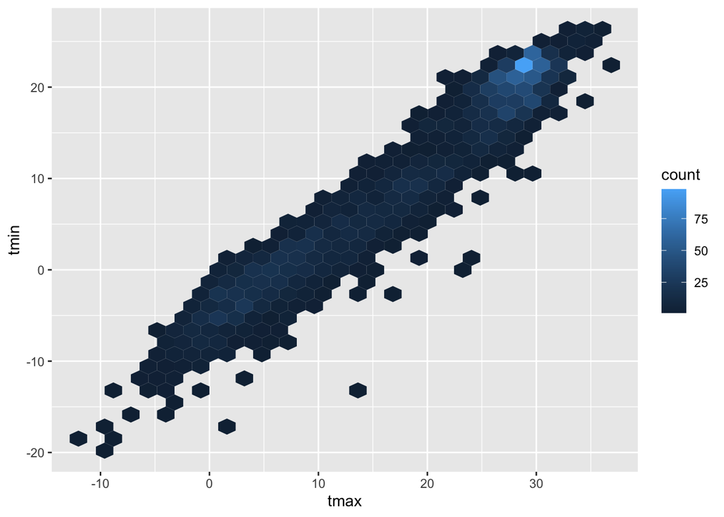

```r
weather_df |>
  ggplot(aes(x = tmax, y = tmin)) +
  geom_hex()
```

# Learning Assessment: In the preceding, we set the alpha aesthetic “by hand” instead of mapping it to a variable. This is possible for other aesthetics too. To check your understanding of this point, try to explain why the two lines below don’t produce the same result:

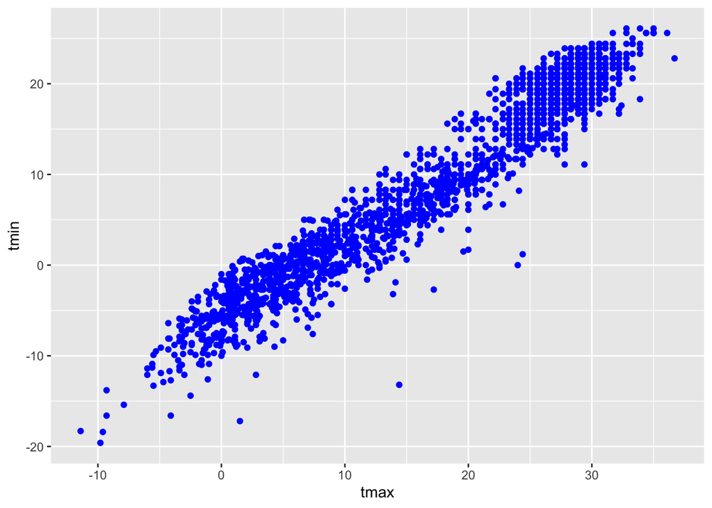

```r
weather_df |> ggplot() + geom_point(aes(x = tmax, y = tmin), color = "blue")
```

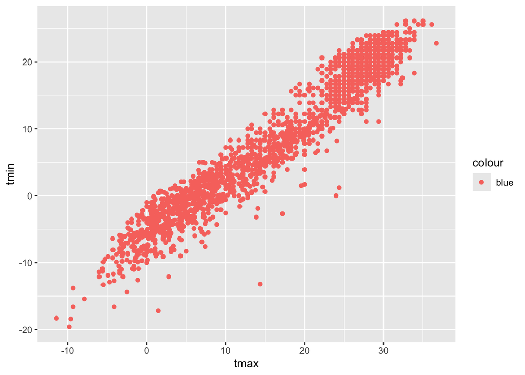

```r
weather_df |> ggplot() + geom_point(aes(x = tmax, y = tmin, color = "blue"))
```

# color is either inside or outside of the aes parentheses - outside actually produces blue, while inside produces orange?

# Solution: In the first attempt, we’re defining the color of the points by hand; in the second attempt, we’re implicitly creating a color variable that has the value blue everywhere; ggplot is then assigning colors according to this variable using the default color scheme.

# Univariate plots

#Histogram

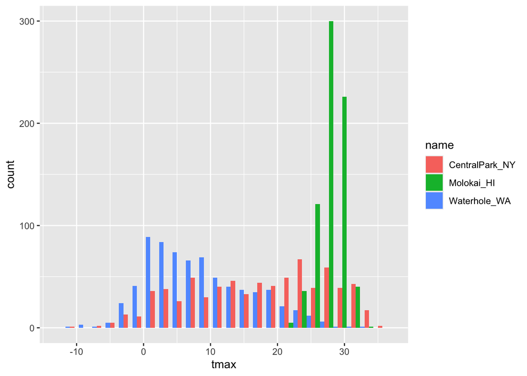

```r
weather_df |>
  ggplot(aes(x = tmax, fill = name)) +
  geom_histogram(position = "dodge", binwidth = 2)
```

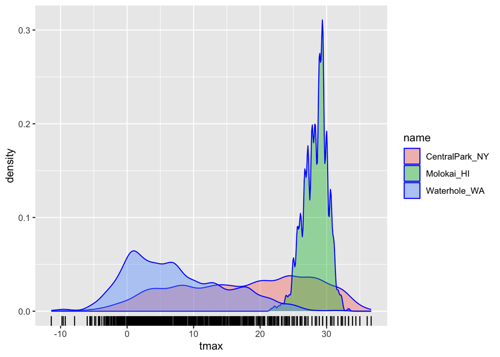

```r
weather_df |>
  ggplot(aes(x = tmax, fill = name)) +
  geom_density(alpha = .4, adjust = .5, color = "blue") +
  geom_rug()
```

# boxplots

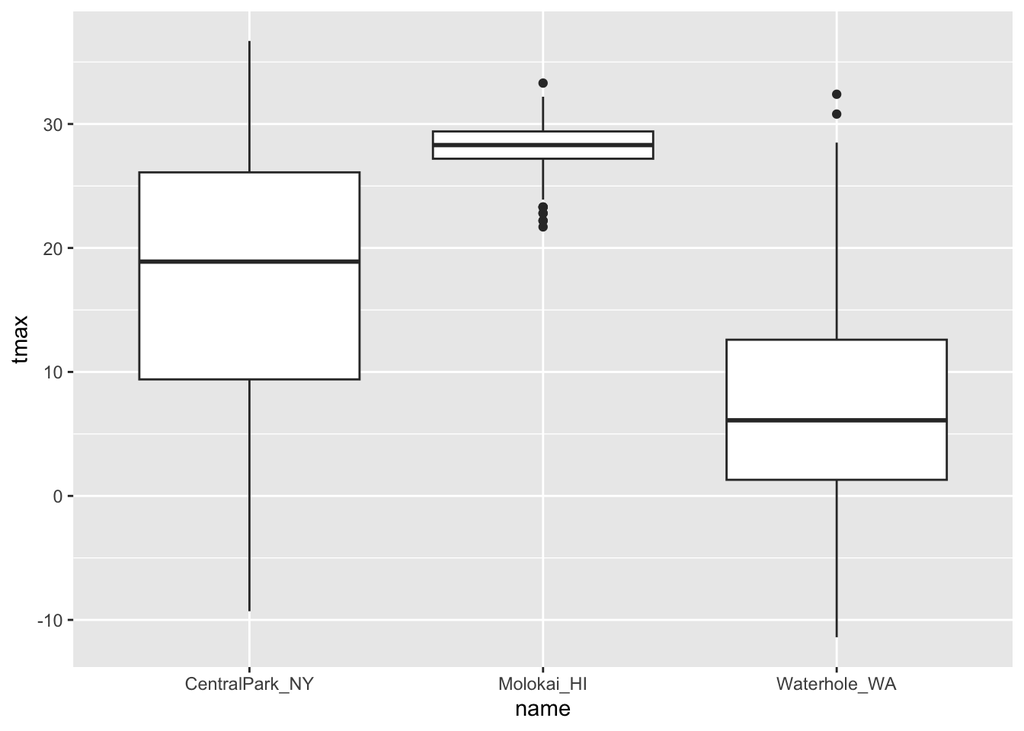

```r
weather_df |>
  ggplot(aes(x = name, y = tmax)) +
  geom_boxplot()
```

# Violin plots

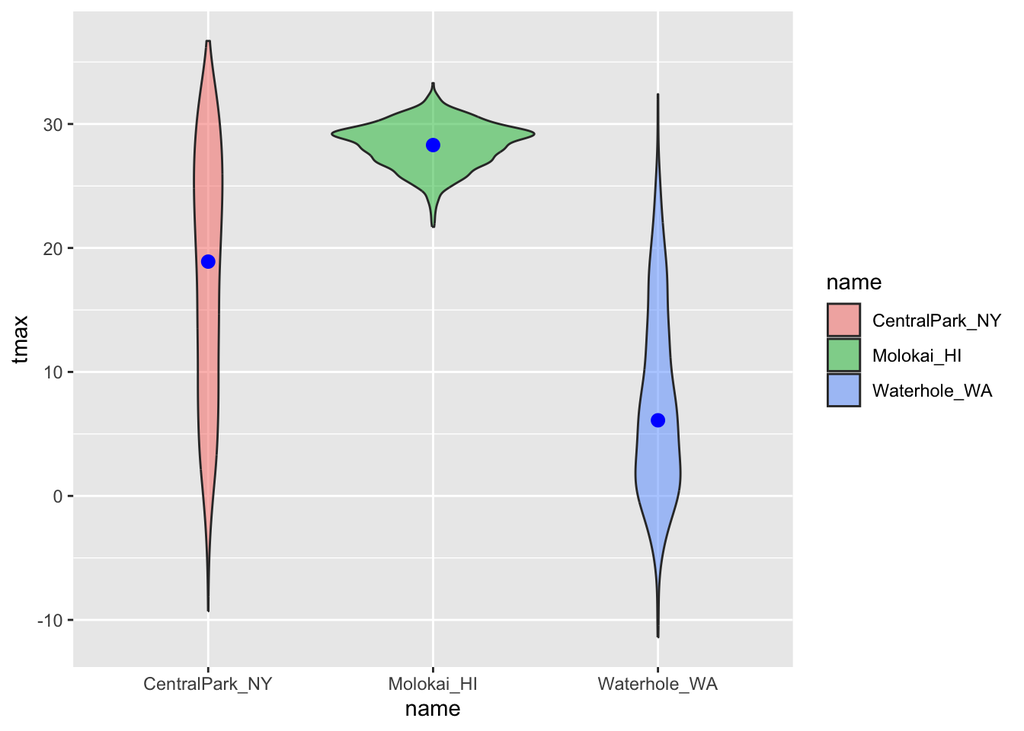

```r
weather_df |>
  ggplot(aes(x = name, y = tmax)) +
  geom_violin(aes(fill = name), alpha = .5) +
  stat_summary(fun = "median", color = "blue")
```

# Ridge plot

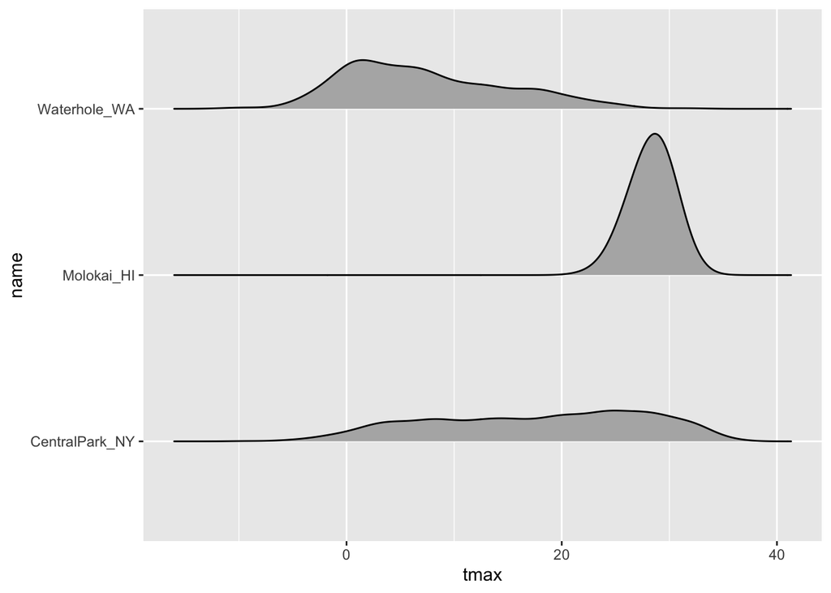

```r
weather_df |>
  ggplot(aes(x = tmax, y = name)) +
  geom_density_ridges(scale = .85)
```

# Learning Assessment: Make plots that compare precipitation across locations. Try a histogram, a density plot, a boxplot, a violin plot, and a ridgeplot; use aesthetic mappings to make your figure readable.

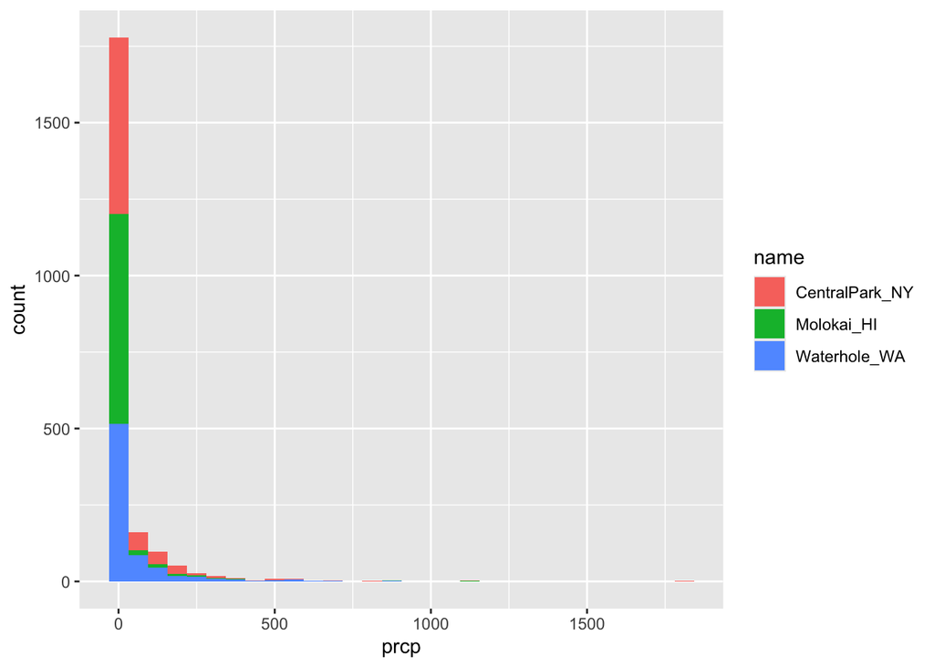

```r
weather_df |>
  ggplot(aes(x = prcp, fill = name)) +
  geom_histogram()
```

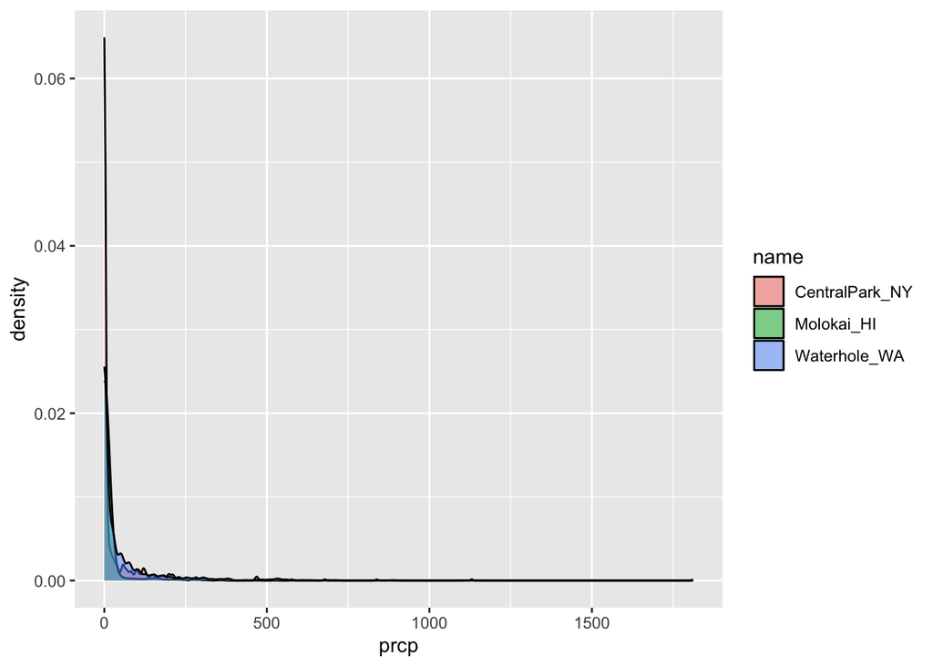

```r
weather_df |>
  ggplot(aes(x = prcp)) +
  geom_density(aes(fill = name), alpha = .5)
```

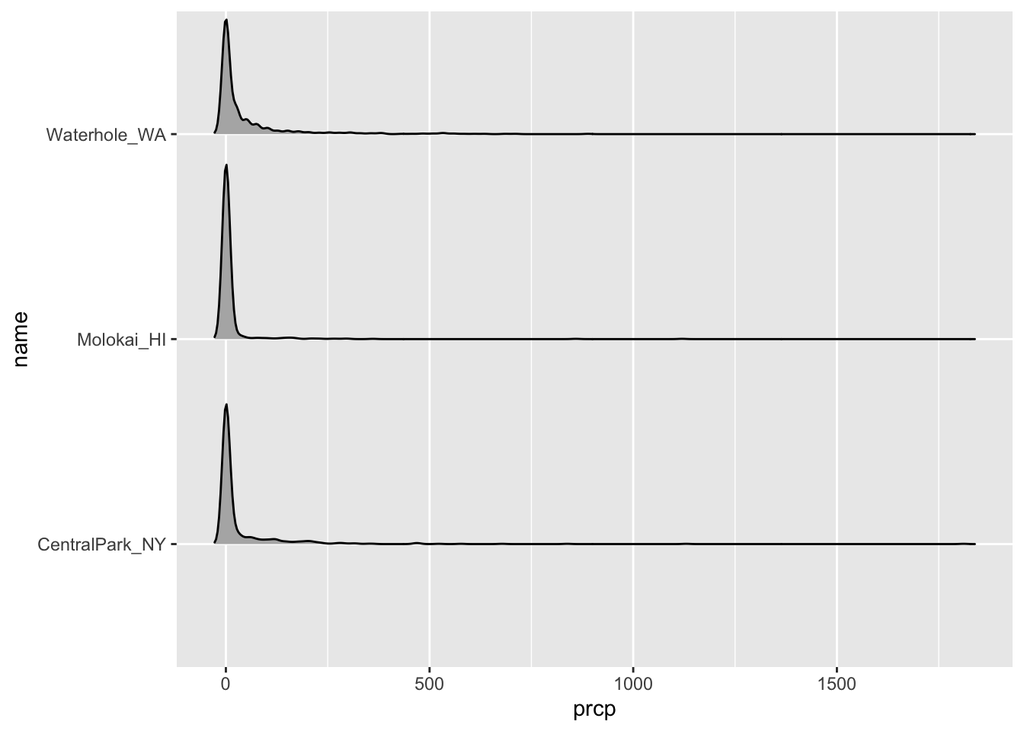

```r
weather_df |>
  ggplot(aes(x = prcp, y = name)) +
  geom_density_ridges(scale = .85)
```

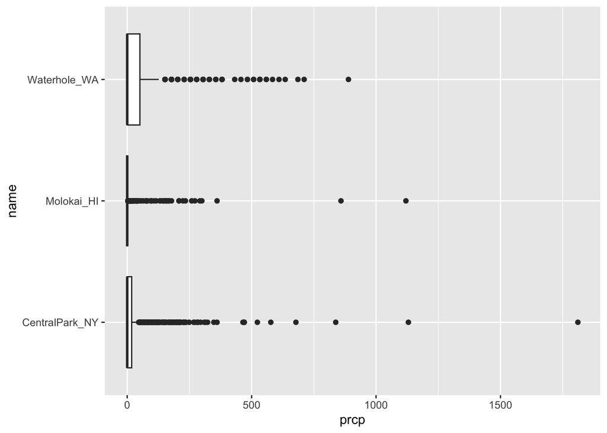

```r
weather_df |>
  ggplot(aes(x = prcp, y = name)) +
  geom_boxplot()
```

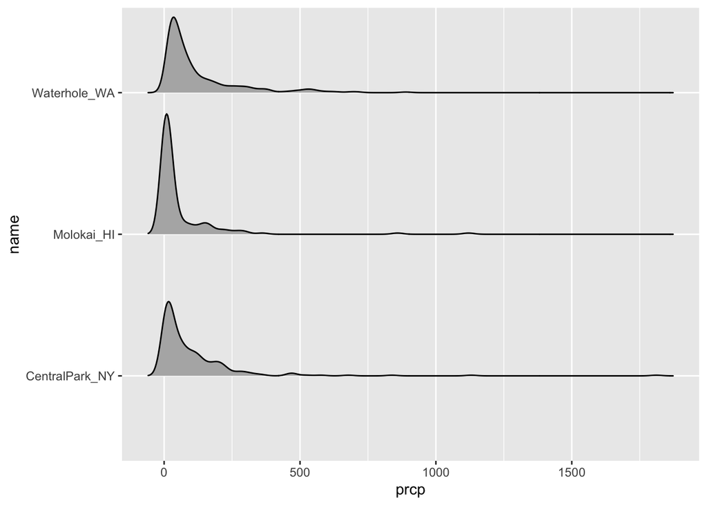

```r
weather_df |>
  filter(prcp > 0) |>
  ggplot(aes(x = prcp, y = name)) +
  geom_density_ridges(scale = .85)
```

# saving and embedding plots

```r
ggp_weather =
  weather_df |>
  ggplot(aes(x = tmin, y = tmax)) +
  geom_point(aes(color = name), alpha = .5)

ggsave("ggp_weather.pdf", ggp_weather, width = 8, height = 5)
knitr::opts_chunk$set(
  fig.width = 6,
  fig.asp = .8,
  out.width = "90%"
)
```

# Learning Assessment: Set global options for your figure sizes in the “setup” code chunk and re-knit your document. What happens when you change fig.asp? What about out.width?